# introduction-to-text-analysis-in-r-chapter-3

Xiaotian Sun

09/02/2020

## 3. Sentiment Analysis

##### 3.1 Sentiment dictionaries (video)

- The tidytext pacakage includes four distinct sentiment dictionaries that can be accessed with the get_sentiments() function. The only argument is the name of the dictionary.
- dictionary: `bing`, `afinn`, `loughran`, `nrc`.

##### 3.2 Counting the NRC sentiments

The fourth dictionary included with the tidytext package is the `nrc` dictionary. Let’s start our exploration with sentiment counts.

*Instruction :*

```r
# Load the tidyverse and tidytext packages
library(tidyverse)
library(tidytext)

# Count the number of words associated with each sentiment in nrc
get_sentiments("nrc") %>%
  count(sentiment) %>%
  # Arrange the counts in descending order
  arrange(desc(n))
```

```
## # A tibble: 10 x 2
##    sentiment        n
##    <chr>        <int>
##  1 negative      3324
##  2 positive      2312
##  3 fear          1476
##  4 anger         1247
##  5 trust         1231
##  6 sadness       1191
##  7 disgust       1058
##  8 anticipation   839
##  9 joy            689
## 10 surprise       534
```

##### 3.3 Visualizing the NRC sentiments

We’ve seen how visualizations can give us a better idea of patterns in data than counts alone. Let’s visualize the sentiments from the `nrc` dictionary. I’ve loaded the `tidyverse` and `tidytext` packages for you already.

*Instruction :*

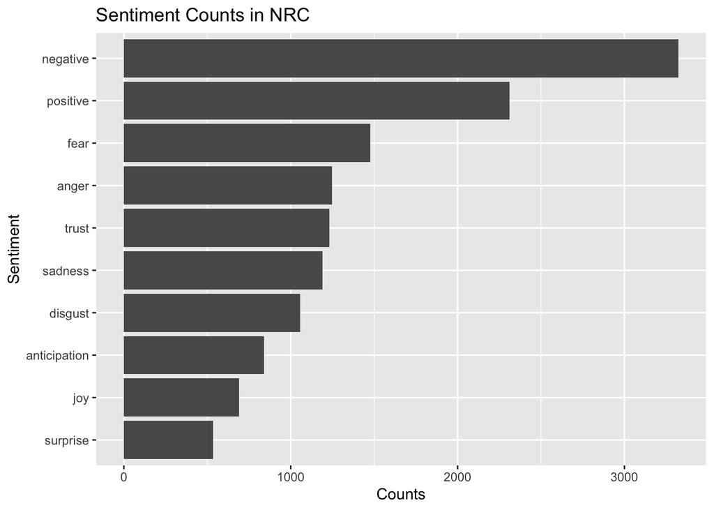

```r
# Pull in the nrc dictionary, count the sentiments and reorder them by count
sentiment_counts <- get_sentiments("nrc") %>%
  count(sentiment) %>%
  mutate(sentiment2 = fct_reorder(sentiment, n))

# Visualize sentiment_counts using the new sentiment factor column
ggplot(sentiment_counts, aes(x = sentiment2, y = n)) +
  geom_col() +
  coord_flip() +
  # Change the title to "Sentiment Counts in NRC", x-axis to "Sentiment", and y-axis to "Counts"
  labs(
    title = "Sentiment Counts in NRC",
    x = "Sentiment",
    y = "Counts"
  )
```

##### 3.4 Appending dictionaries (video)

- We need to first append the sentiment dictionary to our tokenized and cleaned text data.
- inner_join()
- We use `scales = "free"` to set both axes free with “free”.

##### 3.5 Counting sentiment

The `tidy_twitter` dataset has been loaded for you. Let’s see what sort of sentiments are most prevalent in our Twitter data.

*Instruction :*

```r
# Join tidy_twitter and the NRC sentiment dictionary
sentiment_twitter <- tidy_twitter %>%
  inner_join(get_sentiments("nrc"))
# Count the sentiments in sentiment_twitter
sentiment_twitter %>%
  count(sentiment) %>%
  # Arrange the sentiment counts in descending order
  arrange(desc(n))
```

```
## # A tibble: 10 x 2
##    sentiment        n
##    <chr>        <int>
##  1 positive      4415
##  2 trust         2873
##  3 negative      2747
##  4 anticipation  2124
##  5 joy           1480
##  6 sadness       1426
##  7 fear          1357
##  8 anger         1156
##  9 surprise       992
## 10 disgust        880
```

##### 3.6 Visualizing sentiment

Let’s explore which words are associated with each sentiment in our Twitter data.

*Instruction 1:*

```r
word_counts <- tidy_twitter %>%
  # Append the NRC dictionary and filter for positive, fear, and trust
  inner_join(get_sentiments("nrc")) %>%
  filter(sentiment %in% c("positive", "fear", "trust")) %>%
  # Count by word and sentiment and keep the top 10 of each
  count(word, sentiment) %>%
  group_by(sentiment) %>%
  top_n(10, n) %>%
  ungroup() %>%
  # Create a factor called word2 that has each word ordered by the count
  mutate(word2 = fct_reorder(word, n))
```

*Instruction 2:*

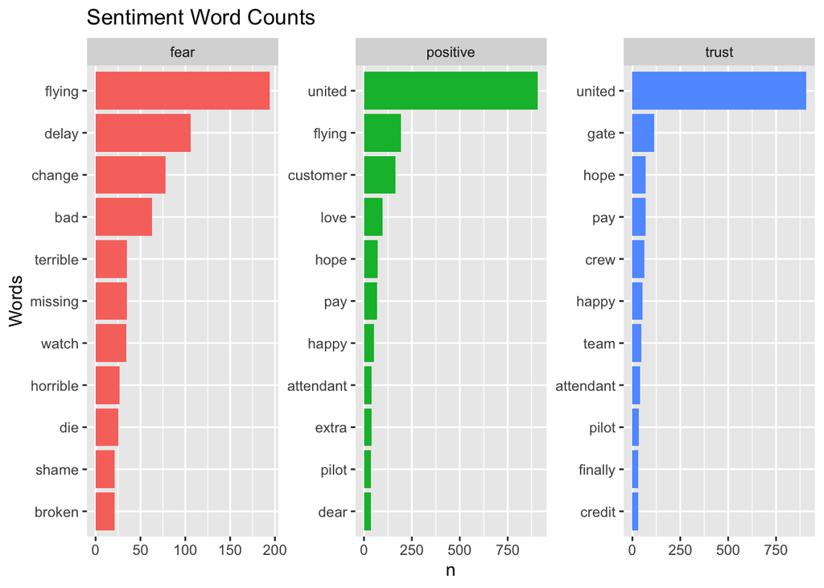

```r
# Create a bar plot out of the word counts colored by sentiment
ggplot(word_counts, aes(x = word2, y = n, fill = sentiment)) +
  geom_col(show.legend = FALSE) +
  # Create a separate facet for each sentiment with free axes
  facet_wrap(~ sentiment, scales ="free") +
  coord_flip() +
  # Title the plot "Sentiment Word Counts" with "Words" for the x-axis
  labs(
    title = "Sentiment Word Counts",
    x = "Words"
  )
```

##### 3.7 Improving sentiment analysis (video)

- spread()

##### 3.8 Practicing reshaping data

The `spread()` verb allows us to quickly reshape or stack and transpose our data, making it easier to `mutate()`.

*Instruction :*

```r
tidy_twitter %>%
  # Append the NRC sentiment dictionary
  inner_join(get_sentiments("nrc")) %>%
  # Count by complaint label and sentiment
  count(complaint_label, sentiment) %>%
  # Spread the sentiment and count columns
  spread(sentiment, n)
```

```
## # A tibble: 2 x 11
##   complaint_label anger anticipation disgust  fear   joy negative positive
##   <chr>           <int>        <int>   <int> <int> <int>    <int>    <int>
## 1 Complaint         559          730     439   552   372     1272     1392
## 2 Non-Complaint     597         1394     441   805  1108     1475     3023
## # … with 3 more variables: sadness <int>, surprise <int>, trust <int>
```

##### 3.9 Practicing with grouped summaries

We can use `spread()` in association with the output of grouped summaries as well.

*Instruction :*

```r
tidy_twitter %>%
  # Append the afinn sentiment dictionary
  inner_join(get_sentiments("afinn")) %>%
  # Group by both complaint label and whether or not the user is verified
  group_by(complaint_label, usr_verified) %>%
  # Summarize the data with an aggregate_value = sum(value)
  summarise(aggregate_value = sum(value)) %>%
  # Spread the complaint_label and aggregate_value columns
  spread(complaint_label, aggregate_value) %>%
  mutate(overall_sentiment = Complaint + `Non-Complaint`)
```

```
## # A tibble: 2 x 4
##   usr_verified Complaint `Non-Complaint` overall_sentiment
##   <lgl>            <dbl>           <dbl>             <dbl>
## 1 FALSE            -1556            2348               792
## 2 TRUE               -12              63                51
```

##### 3.10 Visualizing sentiment by complaint type

Now let’s see whether or not complaints really are more negative, on average.

*Instruction 1:*

```r
sentiment_twitter <- tidy_twitter %>%
  # Append the bing sentiment dictionary
  inner_join(get_sentiments("bing")) %>%
  # Count by complaint label and sentiment
  count(complaint_label, sentiment) %>%
  # Spread the sentiment and count columns
  spread(sentiment, n) %>%
  # Compute overall_sentiment = positive - negative
  mutate(overall_sentiment = positive - negative)
```

*Instruction 2:*

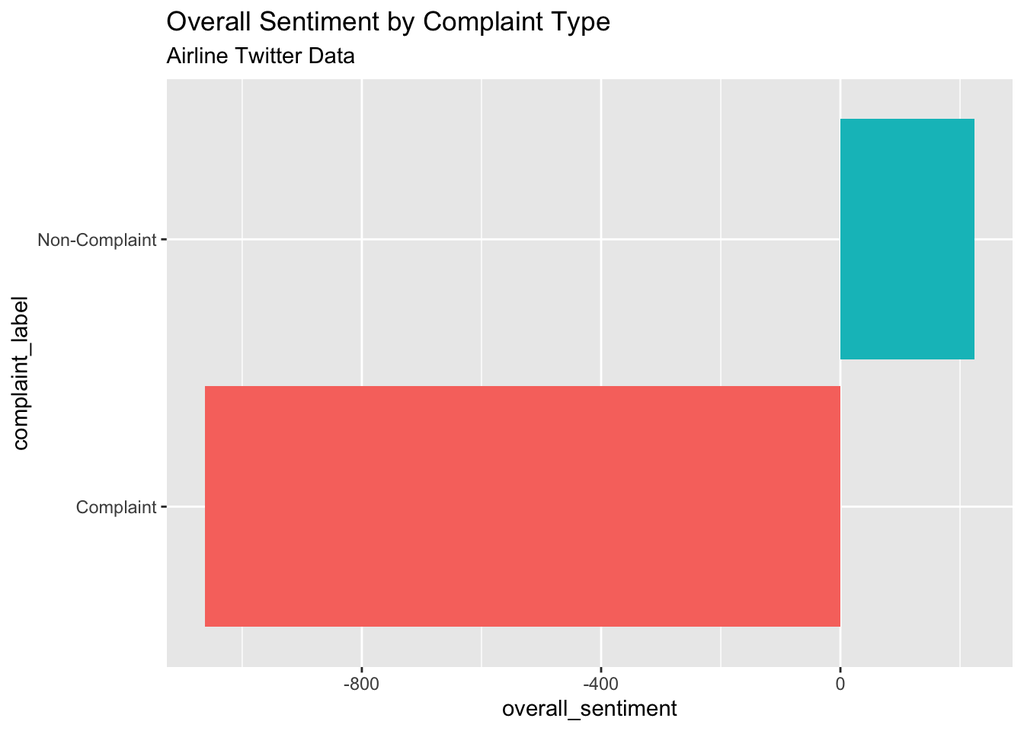

```r
# Create a bar plot out of overall sentiment by complaint level, colored by a complaint label factor
ggplot(
  sentiment_twitter,
  aes(x = complaint_label, y = overall_sentiment, fill = as.factor(complaint_label))
) +
  geom_col(show.legend = FALSE) +
  coord_flip() +
  # Title the plot "Overall Sentiment by Complaint Type," with an "Airline Twitter Data" subtitle
  labs(
    title = "Overall Sentiment by Complaint Type",
    subtitle = "Airline Twitter Data"
  )
```